# **Malaria Detection**

## **Problem Definition**

#### **Context: Why is this problem important to solve?**

Malaria is a life-threatening disease caused by Plasmodium parasites, transmitted through infected Anopheles mosquito bites. It significantly impacts global health, causing severe complications, especially in children under 5, who are the most vulnerable. Traditional diagnosis is time-consuming and requires high expertise, which can lead to variability in results. Automated detection using AI and ML can improve accuracy and speed, potentially saving many lives.

#### **Objectives: What is the intended goal?**

The goal is to develop an efficient computer vision model that can accurately detect malaria. The model should be able to classify images of red blood cells as either parasitized (infected with malaria) or uninfected, thus aiding in early and accurate diagnosis.

#### **Key Questions: What are the key questions that need to be answered?**

1. How can we leverage AI and ML to improve the accuracy of malaria detection?
2. What are the best deep learning algorithms for this classification task?
3. How can the model be trained to distinguish between parasitized and uninfected red blood cells?
4. What metrics will be used to evaluate the model’s performance?
5. How can this model be implemented in real-world settings for automated diagnosis?

#### **Problem Formulation: What is it that we are trying to solve using data science?**

We aim to solve the problem of slow and potentially inaccurate manual malaria detection by developing a deep learning model that can automatically and accurately classify red blood cell images as parasitized or uninfected. This will streamline the diagnosis process, reduce dependency on human expertise, and ultimately contribute to more timely and effective treatment for malaria patients.

## **Data Description**

There are a total of 24,958 train and 2,600 test images (colored) that we have taken from microscopic images. These images are of the following categories:

**Parasitized:** The parasitized cells contain the Plasmodium parasite which causes malaria  
**Uninfected:** The uninfected cells are free of the Plasmodium parasites

### **Loading libraries**

```python
# !pip install opencv-python
# !pip install keras
# !pip install Pillow
# !pip install matplotlib
# !pip install seaborn
```

```python
# Importing libraries required to load the data
import zipfile

import os

import cv2

from PIL import Image

import numpy as np

import pandas as pd

import matplotlib.pyplot as plt

import seaborn as sns

from sklearn.model_selection import train_test_split

from sklearn.preprocessing import MinMaxScaler

# To ignore warnings
import warnings

from keras.utils import to_categorical

warnings.filterwarnings('ignore')

# Remove the limit from the number of displayed columns and rows. It helps to see the entire dataframe while printing it
pd.set_option("display.max_columns", None)

pd.set_option("display.max_rows", 200)
```

[output not shown]

```python
# Force the use of CPU if GPU resuilts to issues
os.environ['CUDA_VISIBLE_DEVICES'] = '-1'
```

### **Let us load the data**

```python
# Storing the path of the data file from the Google drive
path = 'cell_images.zip'

# The data is provided as a zip file so we need to extract the files from the zip file
with zipfile.ZipFile(path, 'r') as zip_ref:

    zip_ref.extractall()
```

The extracted folder has different folders for train and test data which further contains the different sizes of images for parasitized and uninfected cells within the respective folder name.

The size of all images must be the same and should be converted to 4D arrays so that they can be used as an input for the convolutional neural network. Also, we need to create the labels for both types of images to be able to train and test the model.

Let's do the same for the training data first and then we will use the same code for the test data as well.

```python
# Storing the path of the extracted "train" folder
train_dir = 'cell_images/train'

# Size of image so that each image has the same size
SIZE = 64

# Empty list to store the training images after they are converted to NumPy arrays
train_images = []

# Empty list to store the training labels (0 - uninfected, 1 - parasitized)
train_labels = []
```

```python
# We will run the same code for "parasitized" as well as "uninfected" folders within the "train" folder
for folder_name in ['/parasitized/', '/uninfected/']:

    # Path of the folder
    images_path = os.listdir(train_dir + folder_name)

    for i, image_name in enumerate(images_path):

        try:

            # Opening each image using the path of that image
            image = Image.open(train_dir + folder_name + image_name)

            # Resizing each image to (64, 64)
            image = image.resize((SIZE, SIZE))

            # Converting images to arrays and appending that array to the empty list defined above
            train_images.append(np.array(image))

            # Creating labels for parasitized and uninfected images
            if folder_name == '/parasitized/':

                train_labels.append(1)

            else:

                train_labels.append(0)

        except Exception:

            pass

# Converting lists to arrays
train_images = np.array(train_images)

train_labels = np.array(train_labels)
```

```python
# Storing the path of the extracted "test" folder
test_dir = 'cell_images/test'

# Size of image so that each image has the same size (it must be same as the train image size)
SIZE = 64

# Empty list to store the testing images after they are converted to NumPy arrays
test_images = []

# Empty list to store the testing labels (0 - uninfected, 1 - parasitized)
test_labels = []
```

```python
# We will run the same code for "parasitized" as well as "uninfected" folders within the "test" folder
for folder_name in ['/parasitized/', '/uninfected/']:

    # Path of the folder
    images_path = os.listdir(test_dir + folder_name)

    for i, image_name in enumerate(images_path):

        try:
            # Opening each image using the path of that image
            image = Image.open(test_dir + folder_name + image_name)

            # Resizing each image to (64, 64)
            image = image.resize((SIZE, SIZE))

            # Converting images to arrays and appending that array to the empty list defined above
            test_images.append(np.array(image))

            # Creating labels for parasitized and uninfected images
            if folder_name == '/parasitized/':

                test_labels.append(1)

            else:

                test_labels.append(0)

        except Exception:

            pass

# Converting lists to arrays
test_images = np.array(test_images)

test_labels = np.array(test_labels)
```

### **Checking the shape of train and test images**

```python
# Shape of the training images
train_images_shape = train_images.shape
print("Shape of training images:", train_images_shape)

# Shape of the testing images
test_images_shape = test_images.shape
print("Shape of testing images:", test_images_shape)
```

```
Shape of training images: (24958, 64, 64, 3)
Shape of testing images: (2600, 64, 64, 3)
```

```python
# Shape of the training labels
train_labels_shape = train_labels.shape
print("Shape of training labels:", train_labels_shape)

# Shape of the testing labels
test_labels_shape = test_labels.shape
print("Shape of testing labels:", test_labels_shape)
```

```
Shape of training labels: (24958,)
Shape of testing labels: (2600,)
```

### **Check the minimum and maximum range of pixel values for train and test images**

```python
# Minimum and Maximum pixel values for training images
train_min_pixel = np.min(train_images)
train_max_pixel = np.max(train_images)
print("Training Images - Min Pixel Value:", train_min_pixel)
print("Training Images - Max Pixel Value:", train_max_pixel)

# Minimum and Maximum pixel values for testing images
test_min_pixel = np.min(test_images)
test_max_pixel = np.max(test_images)
print("Testing Images - Min Pixel Value:", test_min_pixel)
print("Testing Images - Max Pixel Value:", test_max_pixel)
```

```
Training Images - Min Pixel Value: 0
Training Images - Max Pixel Value: 255
Testing Images - Min Pixel Value: 0
Testing Images - Max Pixel Value: 255
```

### Count the number of values in both uninfected and parasitized

```python
# Count the number of values in training labels
train_label_counts = pd.Series(train_labels).value_counts()
print("Training Labels Count:")
print(train_label_counts)

# Count the number of values in testing labels
test_label_counts = pd.Series(test_labels).value_counts()
print("Testing Labels Count:")
print(test_label_counts)
```

```
Training Labels Count:
1    12582
0    12376
Name: count, dtype: int64
Testing Labels Count:
1    1300
0    1300
Name: count, dtype: int64
```

### Normalize the images

```python
# Normalize the train images
train_images = (train_images / 255.0).astype('float32')

# Normalize the test images
test_images = (test_images / 255.0).astype('float32')
```

### Plot to check if the data is balanced

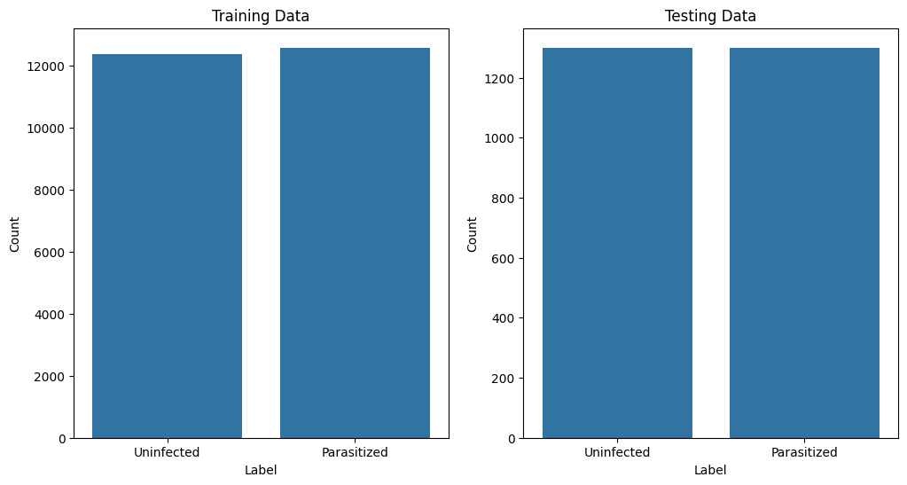

```python
# Plot for training labels
plt.figure(figsize=(12, 6))

plt.subplot(1, 2, 1)
sns.countplot(x=pd.Series(train_labels))
plt.title('Training Data')
plt.xlabel('Label')
plt.ylabel('Count')
plt.xticks([0, 1], ['Uninfected', 'Parasitized'])

# Plot for testing labels
plt.subplot(1, 2, 2)
sns.countplot(x=pd.Series(test_labels))
plt.title('Testing Data')
plt.xlabel('Label')
plt.ylabel('Count')
plt.xticks([0, 1], ['Uninfected', 'Parasitized'])

plt.show()
```

### **Data Exploration**

Let's visualize the images from the train data

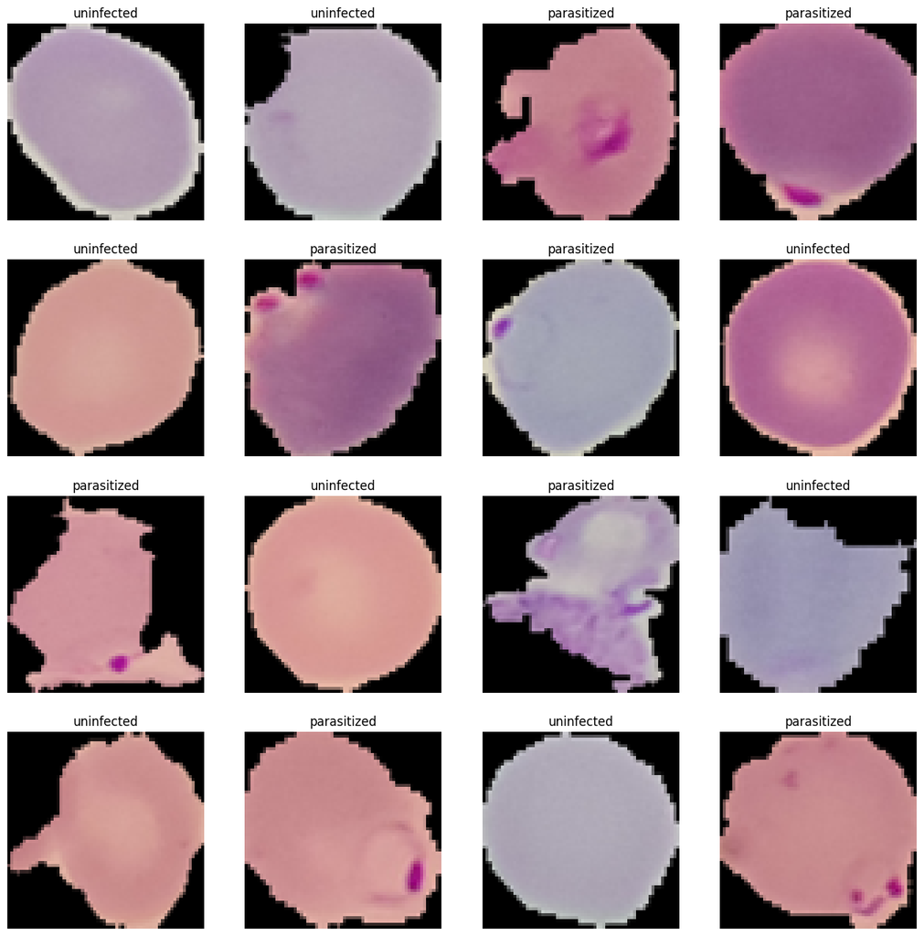

```python
# This code will help you in visualizing both the parasitized and uninfected images
np.random.seed(42)

plt.figure(1, figsize = (16 , 16))

for n in range(1, 17):

    plt.subplot(4, 4, n)

    index = int(np.random.randint(0, train_images.shape[0], 1))

    if train_labels[index] == 1:

        plt.title('parasitized')

    else:
        plt.title('uninfected')

    plt.imshow(train_images[index])

    plt.axis('off')
```

### Similarly visualize the images with subplot(6, 6) and figsize = (12, 12)

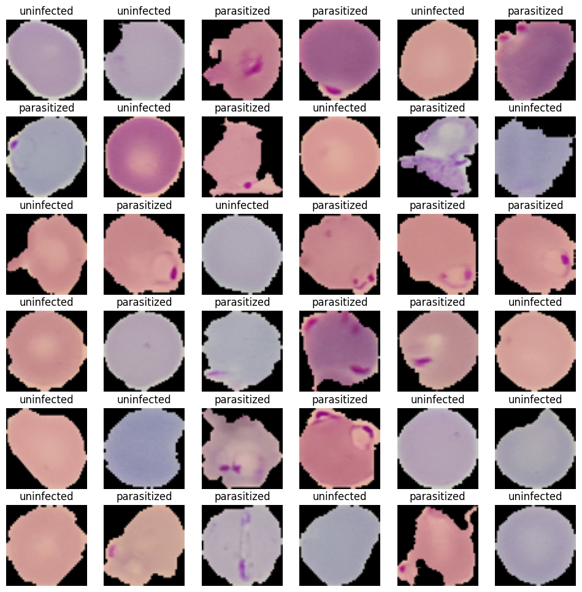

```python
np.random.seed(42)

plt.figure(1, figsize=(12, 12))

for n in range(1, 37):
    plt.subplot(6, 6, n)
    index = int(np.random.randint(0, train_images.shape[0], 1))
    if train_labels[index] == 1:
        plt.title('parasitized')
    else:
        plt.title('uninfected')
    plt.imshow(train_images[index])
    plt.axis('off')

plt.show()
```

### Plotting the mean images for parasitized and uninfected

```python
# Function to find the mean
def find_mean_img(full_mat, title):

    # Calculate the average
    mean_img = np.mean(full_mat, axis = 0)[0]

    # Reshape it back to a matrix
    plt.imshow(mean_img)

    plt.title(f'Average {title}')

    plt.axis('off')

    plt.show()

    return mean_img
```

**Mean image for parasitized**

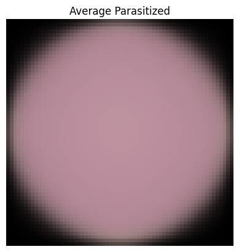

```python
# If the label = 1 then the image is parasitised and if the label = 0 then the image is uninfected
parasitized_data = []  # Create a list to store the parasitized data

for img, label in zip(train_images, train_labels):

        if label == 1:

              parasitized_data.append([img])

parasitized_mean = find_mean_img(np.array(parasitized_data), 'Parasitized')   # find the mean
```

**Mean image for uninfected**

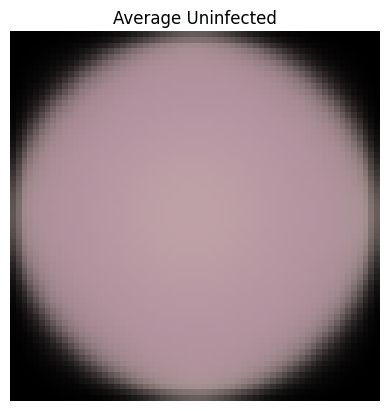

```python
# Function to find the mean
def find_mean_img(full_mat, title):
    # Calculate the average
    mean_img = np.mean(full_mat, axis=0)
    # Reshape it back to a matrix and display it
    plt.imshow(mean_img, cmap='viridis')
    plt.title(f'Average {title}')
    plt.axis('off')
    plt.show()
    return mean_img

# Create a list to store the uninfected data
uninfected_data = []

for img, label in zip(train_images, train_labels):
    if label == 0:
        uninfected_data.append(img)

# Find and plot the mean image for uninfected data
uninfected_mean = find_mean_img(np.array(uninfected_data), 'Uninfected')
```

### **Converting RGB to HSV of Images using OpenCV**

### Converting the train data

```python
import cv2

gfx=[]   # to hold the HSV image array

for i in np.arange(0, 100, 1):

  a = cv2.cvtColor(train_images[i], cv2.COLOR_BGR2HSV)

  gfx.append(a)

gfx = np.array(gfx)
```

[output not shown]

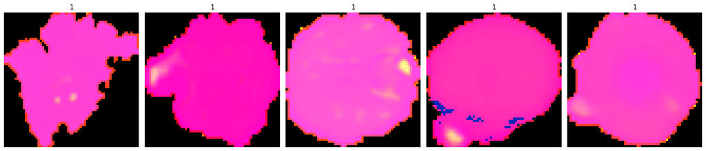

```python
viewimage = np.random.randint(1, 100, 5)

fig, ax = plt.subplots(1, 5, figsize = (18, 18))

for t, i in zip(range(5), viewimage):

  Title = train_labels[i]

  ax[t].set_title(Title)

  ax[t].imshow(gfx[i])

  ax[t].set_axis_off()

  fig.tight_layout()
```

### Converting the test data

```python
# List to hold the HSV image array for test data
test_gfx = []

# Converting the test images from RGB to HSV
for i in np.arange(0, test_images.shape[0], 1):
    # Convert image from RGB to HSV
    hsv_image = cv2.cvtColor(test_images[i], cv2.COLOR_BGR2HSV)
    # Append the HSV image to the list
    test_gfx.append(hsv_image)

# Convert the list to a NumPy array
test_gfx = np.array(test_gfx)
```

[output not shown]

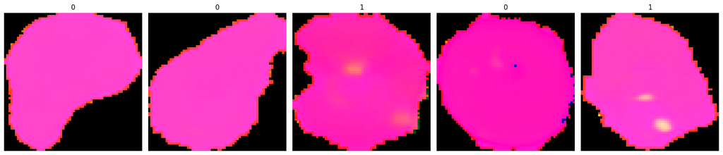

```python
# Select 5 random images to view from the test data
viewimage = np.random.randint(1, test_images.shape[0], 5)

# Create subplots
fig, ax = plt.subplots(1, 5, figsize=(18, 18))

# Loop through the selected images and plot them
for t, i in zip(range(5), viewimage):
    Title = test_labels[i]
    ax[t].set_title(Title)
    ax[t].imshow(test_gfx[i])
    ax[t].set_axis_off()

fig.tight_layout()
plt.show()
```

### Processing Images using Gaussian Blurring

### Gaussian Blurring on train data

```python
gbx = []  # To hold the blurred images

for i in np.arange(0, 100, 1):

  b = cv2.GaussianBlur(train_images[i], (5, 5), 0)

  gbx.append(b)

gbx = np.array(gbx)
```

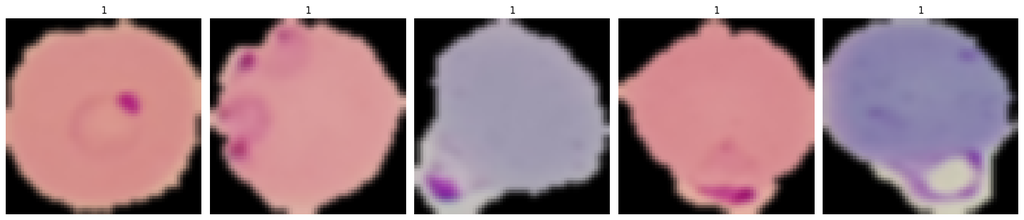

```python
viewimage = np.random.randint(1, 100, 5)

fig, ax = plt.subplots(1, 5, figsize = (18, 18))

for t, i in zip(range(5), viewimage):

  Title = train_labels[i]

  ax[t].set_title(Title)


  ax[t].imshow(gbx[i])

  ax[t].set_axis_off()

  fig.tight_layout()
```

### Gaussian Blurring on test data

```python
# List to hold the blurred images for test data
test_gbx = []

# Applying Gaussian Blurring to the test images
for i in np.arange(0, test_images.shape[0], 1):
    # Apply Gaussian Blurring with a 5x5 kernel
    blurred_image = cv2.GaussianBlur(test_images[i], (5, 5), 0)
    # Append the blurred image to the list
    test_gbx.append(blurred_image)

# Convert the list to a NumPy array
test_gbx = np.array(test_gbx)
```

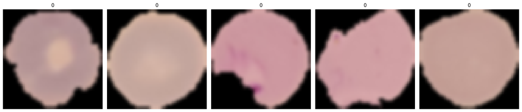

```python
# Select 5 random images to view from the test data
viewimage = np.random.randint(1, test_images.shape[0], 5)

# Create subplots
fig, ax = plt.subplots(1, 5, figsize=(18, 18))

# Loop through the selected images and plot them
for t, i in zip(range(5), viewimage):
    Title = test_labels[i]
    ax[t].set_title(Title)
    ax[t].imshow(test_gbx[i])
    ax[t].set_axis_off()

fig.tight_layout()
plt.show()
```

### One Hot Encoding on the train and test labels

```python
# Encoding Train Labels
train_labels = to_categorical(train_labels, 2)

# Encoding Test Labels
test_labels = to_categorical(test_labels, 2)
```

### **Base Model**

**Note:** The Base Model has been fully built and evaluated with all outputs shown to give an idea about the process of the creation and evaluation of the performance of a CNN architecture. A similar process can be followed in iterating to build better-performing CNN architectures.

### Importing the required libraries for building and training our Model

```python
# Clearing backend
from tensorflow.keras import backend

from tensorflow.keras.utils import to_categorical

from tensorflow.keras.models import Sequential

from tensorflow.keras.layers import Conv2D, MaxPooling2D, Dense, Flatten, Dropout, BatchNormalization, Activation, LeakyReLU

from tensorflow.keras.callbacks import EarlyStopping, ModelCheckpoint

from random import shuffle

backend.clear_session()

# Fixing the seed for random number generators so that we can ensure we receive the same output everytime
np.random.seed(42)

import random

random.seed(42)

import tensorflow as tf

tf.random.set_seed(42)
```

### Building the model

```python
# Creating sequential model
model = Sequential()

model.add(Conv2D(filters = 32, kernel_size = 2, padding = "same", activation = "relu", input_shape = (64, 64, 3)))

model.add(MaxPooling2D(pool_size = 2))

model.add(Dropout(0.2))

model.add(Conv2D(filters = 32, kernel_size = 2, padding = "same", activation = "relu"))

model.add(MaxPooling2D(pool_size = 2))

model.add(Dropout(0.2))

model.add(Conv2D(filters = 32, kernel_size = 2, padding = "same", activation = "relu"))

model.add(MaxPooling2D(pool_size = 2))

model.add(Dropout(0.2))

model.add(Flatten())

model.add(Dense(512, activation = "relu"))

model.add(Dropout(0.4))

model.add(Dense(2, activation = "softmax")) # 2 represents output layer neurons

model.summary()
```

```
2025-01-03 21:19:53.177689: E external/local_xla/xla/stream_executor/cuda/cuda_driver.cc:266] failed call to cuInit: CUDA_ERROR_NO_DEVICE: no CUDA-capable device is detected
```

```
Model: "sequential"
_________________________________________________________________
 Layer (type)                Output Shape              Param #
=================================================================
 conv2d (Conv2D)             (None, 64, 64, 32)        416

 max_pooling2d (MaxPooling2  (None, 32, 32, 32)        0
 D)

 dropout (Dropout)           (None, 32, 32, 32)        0

 conv2d_1 (Conv2D)           (None, 32, 32, 32)        4128

 max_pooling2d_1 (MaxPoolin  (None, 16, 16, 32)        0
 g2D)

 dropout_1 (Dropout)         (None, 16, 16, 32)        0

 conv2d_2 (Conv2D)           (None, 16, 16, 32)        4128

 max_pooling2d_2 (MaxPoolin  (None, 8, 8, 32)          0
 g2D)

 dropout_2 (Dropout)         (None, 8, 8, 32)          0

 flatten (Flatten)           (None, 2048)              0

 dense (Dense)               (None, 512)               1049088

 dropout_3 (Dropout)         (None, 512)               0

 dense_1 (Dense)             (None, 2)                 1026

=================================================================
Total params: 1058786 (4.04 MB)
Trainable params: 1058786 (4.04 MB)
Non-trainable params: 0 (0.00 Byte)
_________________________________________________________________
```

### Compiling the model

```python
model.compile(loss = 'binary_crossentropy', optimizer = 'adam', metrics = ['accuracy'])
```

**Using Callbacks**

```python
callbacks = [EarlyStopping(monitor = 'val_loss', patience = 2),
             ModelCheckpoint('.mdl_wts.hdf5', monitor = 'val_loss', save_best_only = True)]
```

### Fit and train our Model

```python
# Train the model with one-hot encoded labels
history = model.fit(train_images, train_labels, batch_size=32, callbacks=callbacks, validation_split=0.2, epochs=20, verbose=1)
```

```python
# One-hot encode the test labels
test_labels_encoded = to_categorical(test_labels, num_classes=2)
```

### Evaluating the model on test data

```python
# Evaluate the model with one-hot encoded labels
accuracy = model.evaluate(test_images, test_labels, verbose=1)
print('\n', 'Test_Accuracy:-', accuracy[1])
```

```
 Test_Accuracy:- 0.9834615588188171
```

**Plotting the confusion matrix**

```
              precision    recall  f1-score   support

           0       0.98      0.99      0.98      1300
           1       0.99      0.98      0.98      1300

    accuracy                           0.98      2600
   macro avg       0.98      0.98      0.98      2600
weighted avg       0.98      0.98      0.98      2600
```

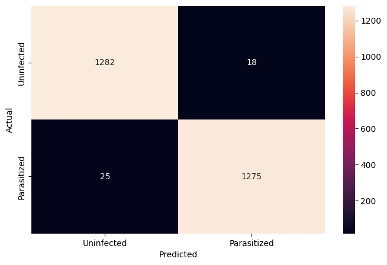

```python
from sklearn.metrics import classification_report

from sklearn.metrics import confusion_matrix

pred = model.predict(test_images)

pred = np.argmax(pred, axis = 1)

y_true = np.argmax(test_labels, axis = 1)

# Printing the classification report
print(classification_report(y_true, pred))

# Plotting the heatmap using confusion matrix
cm = confusion_matrix(y_true, pred)

plt.figure(figsize = (8, 5))

sns.heatmap(cm, annot = True,  fmt = '.0f', xticklabels = ['Uninfected', 'Parasitized'], yticklabels = ['Uninfected', 'Parasitized'])

plt.ylabel('Actual')

plt.xlabel('Predicted')

plt.show()
```

**Plotting the train and validation curves**

```python
# Function to plot train and validation accuracy
def plot_accuracy(history):

    N = len(history.history["accuracy"])

    plt.figure(figsize = (7, 7))

    plt.plot(np.arange(0, N), history.history["accuracy"], label = "train_accuracy", ls = '--')

    plt.plot(np.arange(0, N), history.history["val_accuracy"], label = "val_accuracy", ls = '--')

    plt.title("Accuracy vs Epoch")

    plt.xlabel("Epochs")

    plt.ylabel("Accuracy")

    plt.legend(loc="upper left")
```

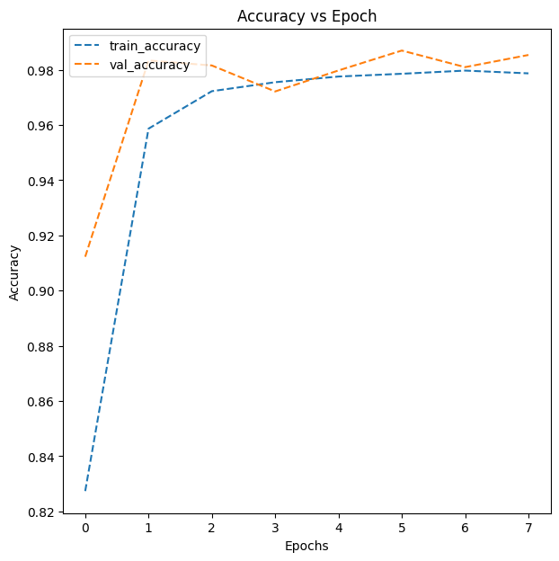

```python
plot_accuracy(history)
```

- Here we can clearly observe that the training and valiation accuracy are increasing
- And we can also notice that validation accuracy is slightly higher than the train accuracy

So now let's try to build another model with few more add on layers and try to check if we can try to improve the model. Therefore try to build a model by adding few layers if required and altering the activation functions.

### Model 1

#### Trying to improve the performance of our model by adding new layers

```python
backend.clear_session() # Clearing the backend for new model
```

### Building the Model

```python
# Create a sequential model
model1 = Sequential()

# Adding new layers and altering activation functions
model1.add(Conv2D(filters=64, kernel_size=3, padding="same", input_shape=(64, 64, 3)))
model1.add(BatchNormalization())
model1.add(Activation("relu"))
model1.add(MaxPooling2D(pool_size=2))
model1.add(Dropout(0.25))

model1.add(Conv2D(filters=128, kernel_size=3, padding="same"))
model1.add(BatchNormalization())
model1.add(Activation("relu"))
model1.add(MaxPooling2D(pool_size=2))
model1.add(Dropout(0.3))

model1.add(Conv2D(filters=256, kernel_size=3, padding="same"))
model1.add(BatchNormalization())
model1.add(Activation("relu"))
model1.add(MaxPooling2D(pool_size=2))
model1.add(Dropout(0.35))

model1.add(Conv2D(filters=512, kernel_size=3, padding="same"))
model1.add(BatchNormalization())
model1.add(Activation("relu"))
model1.add(MaxPooling2D(pool_size=2))
model1.add(Dropout(0.4))

# Flatten the output from the convolutional layers
model1.add(Flatten())

# Add dense layers
model1.add(Dense(units=512))
model1.add(BatchNormalization())
model1.add(Activation("relu"))
model1.add(Dropout(0.5))

# Add the output layer
model1.add(Dense(units=2, activation="softmax"))

# Print the model summary
model1.summary()
```

```
Model: "sequential"
_________________________________________________________________
 Layer (type)                Output Shape              Param #
=================================================================
 conv2d (Conv2D)             (None, 64, 64, 64)        1792

 batch_normalization (Batch  (None, 64, 64, 64)        256
 Normalization)

 activation (Activation)     (None, 64, 64, 64)        0

 max_pooling2d (MaxPooling2  (None, 32, 32, 64)        0
 D)

 dropout (Dropout)           (None, 32, 32, 64)        0

 conv2d_1 (Conv2D)           (None, 32, 32, 128)       73856

 batch_normalization_1 (Bat  (None, 32, 32, 128)       512
 chNormalization)

 activation_1 (Activation)   (None, 32, 32, 128)       0

 max_pooling2d_1 (MaxPoolin  (None, 16, 16, 128)       0
 g2D)

 dropout_1 (Dropout)         (None, 16, 16, 128)       0

 conv2d_2 (Conv2D)           (None, 16, 16, 256)       295168

 batch_normalization_2 (Bat  (None, 16, 16, 256)       1024
 chNormalization)

 activation_2 (Activation)   (None, 16, 16, 256)       0

 max_pooling2d_2 (MaxPoolin  (None, 8, 8, 256)         0
 g2D)

 dropout_2 (Dropout)         (None, 8, 8, 256)         0

```

[output cut: 15 more lines]

```

 batch_normalization_4 (Bat  (None, 512)               2048
 chNormalization)

 activation_4 (Activation)   (None, 512)               0

 dropout_4 (Dropout)         (None, 512)               0

 dense_1 (Dense)             (None, 2)                 1026

=================================================================
Total params: 5752706 (21.94 MB)
Trainable params: 5749762 (21.93 MB)
Non-trainable params: 2944 (11.50 KB)
_________________________________________________________________
```

### Compiling the model

```python
model1.compile(loss='binary_crossentropy', optimizer='adam', metrics=['accuracy'])
```

**Using Callbacks**

```python
callbacks = [EarlyStopping(monitor = 'val_loss', patience = 2),
             ModelCheckpoint('.mdl_wts.hdf5', monitor = 'val_loss', save_best_only = True)]
```

**Fit and Train the model**

```python
history1 = model1.fit(train_images, train_labels, batch_size=32, callbacks=callbacks, validation_split=0.2, epochs=20, verbose=1)
```

### Evaluating the model

```python
accuracy1 = model1.evaluate(test_images, test_labels, verbose=1)

print('\n', 'Test_Accuracy:-', accuracy1[1])
```

```
 Test_Accuracy:- 0.9684615135192871
```

```
              precision    recall  f1-score   support

           0       0.95      0.99      0.97      1300
           1       0.99      0.94      0.97      1300

    accuracy                           0.97      2600
   macro avg       0.97      0.97      0.97      2600
weighted avg       0.97      0.97      0.97      2600
```

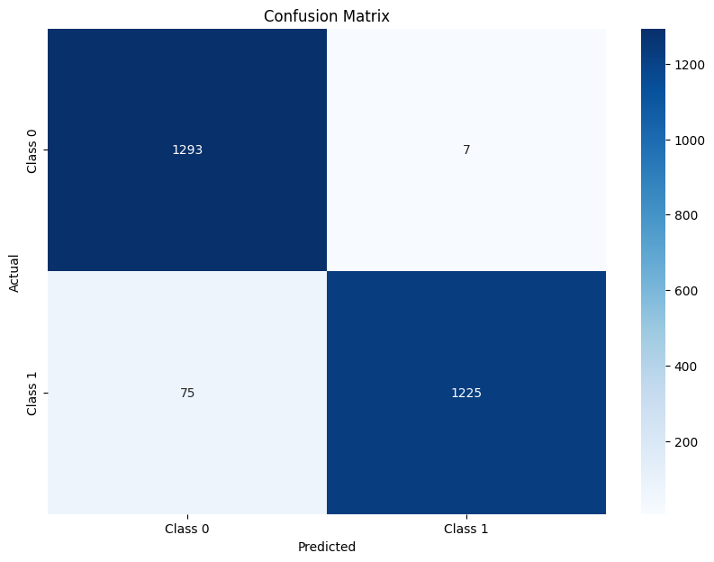

```python
predictions = model1.predict(test_images)

# Convert predictions and true labels to class indices
y_pred = np.argmax(predictions, axis=1)
y_true = np.argmax(test_labels, axis=1)

# Printing the classification report
print(classification_report(y_true, y_pred))

cm = confusion_matrix(y_true, y_pred)

plt.figure(figsize=(10, 7))
sns.heatmap(cm, annot=True, fmt='d', cmap='Blues', xticklabels=['Class 0', 'Class 1'], yticklabels=['Class 0', 'Class 1'])
plt.xlabel('Predicted')
plt.ylabel('Actual')
plt.title('Confusion Matrix')
plt.show()
```

**Plotting the train and the validation curves**

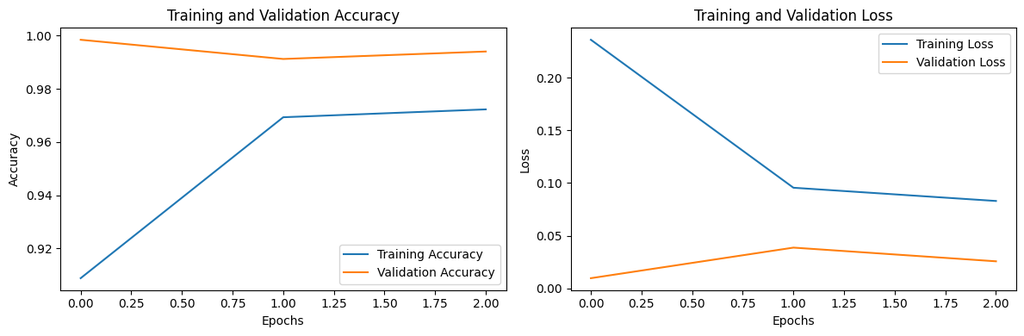

```python
# Get training and validation accuracy and loss from the history object
train_accuracy = history1.history['accuracy']
val_accuracy = history1.history['val_accuracy']
train_loss = history1.history['loss']
val_loss = history1.history['val_loss']

# Plot training and validation accuracy
plt.figure(figsize=(12, 4))
plt.subplot(1, 2, 1)
plt.plot(train_accuracy, label='Training Accuracy')
plt.plot(val_accuracy, label='Validation Accuracy')
plt.xlabel('Epochs')
plt.ylabel('Accuracy')
plt.title('Training and Validation Accuracy')
plt.legend()

# Plot training and validation loss
plt.subplot(1, 2, 2)
plt.plot(train_loss, label='Training Loss')
plt.plot(val_loss, label='Validation Loss')
plt.xlabel('Epochs')
plt.ylabel('Loss')
plt.title('Training and Validation Loss')
plt.legend()

# Show plots
plt.tight_layout()
plt.show()
```

### Let's try to build a model using LeakyRelu as our activation function.

### Model 2 with Batch Normalization

```python
backend.clear_session() # Clearing the backend for new model
```

### Building the Model

```python
# Create a sequential model
model2 = Sequential()

# Adding new layers and altering activation functions to LeakyReLU
model2.add(Conv2D(filters=64, kernel_size=3, padding="same", input_shape=(64, 64, 3)))
model2.add(BatchNormalization())
model2.add(LeakyReLU(alpha=0.1))
model2.add(MaxPooling2D(pool_size=2))
model2.add(Dropout(0.25))

model2.add(Conv2D(filters=128, kernel_size=3, padding="same"))
model2.add(BatchNormalization())
model2.add(LeakyReLU(alpha=0.1))
model2.add(MaxPooling2D(pool_size=2))
model2.add(Dropout(0.3))

model2.add(Conv2D(filters=256, kernel_size=3, padding="same"))
model2.add(BatchNormalization())
model2.add(LeakyReLU(alpha=0.1))
model2.add(MaxPooling2D(pool_size=2))
model2.add(Dropout(0.35))

model2.add(Conv2D(filters=512, kernel_size=3, padding="same"))
model2.add(BatchNormalization())
model2.add(LeakyReLU(alpha=0.1))
model2.add(MaxPooling2D(pool_size=2))
model2.add(Dropout(0.4))

# Flatten the output from the convolutional layers
model2.add(Flatten())

# Add dense layers
model2.add(Dense(units=512))
model2.add(BatchNormalization())
model2.add(LeakyReLU(alpha=0.1))
model2.add(Dropout(0.5))

# Add the output layer
model2.add(Dense(units=2, activation='softmax'))

# Print the model summary
model2.summary()
```

```
Model: "sequential_1"
_________________________________________________________________
 Layer (type)                Output Shape              Param #
=================================================================
 conv2d_4 (Conv2D)           (None, 64, 64, 64)        1792

 batch_normalization_5 (Bat  (None, 64, 64, 64)        256
 chNormalization)

 leaky_re_lu_5 (LeakyReLU)   (None, 64, 64, 64)        0

 max_pooling2d_4 (MaxPoolin  (None, 32, 32, 64)        0
 g2D)

 dropout_5 (Dropout)         (None, 32, 32, 64)        0

 conv2d_5 (Conv2D)           (None, 32, 32, 128)       73856

 batch_normalization_6 (Bat  (None, 32, 32, 128)       512
 chNormalization)

 leaky_re_lu_6 (LeakyReLU)   (None, 32, 32, 128)       0

 max_pooling2d_5 (MaxPoolin  (None, 16, 16, 128)       0
 g2D)

 dropout_6 (Dropout)         (None, 16, 16, 128)       0

 conv2d_6 (Conv2D)           (None, 16, 16, 256)       295168

 batch_normalization_7 (Bat  (None, 16, 16, 256)       1024
 chNormalization)

 leaky_re_lu_7 (LeakyReLU)   (None, 16, 16, 256)       0

 max_pooling2d_6 (MaxPoolin  (None, 8, 8, 256)         0
 g2D)

 dropout_7 (Dropout)         (None, 8, 8, 256)         0

```

[output cut: 15 more lines]

```

 batch_normalization_9 (Bat  (None, 512)               2048
 chNormalization)

 leaky_re_lu_9 (LeakyReLU)   (None, 512)               0

 dropout_9 (Dropout)         (None, 512)               0

 dense_3 (Dense)             (None, 2)                 1026

=================================================================
Total params: 5752706 (21.94 MB)
Trainable params: 5749762 (21.93 MB)
Non-trainable params: 2944 (11.50 KB)
_________________________________________________________________
```

### Compiling the model

```python
model2.compile(loss = "binary_crossentropy", optimizer = 'adam', metrics = ['accuracy'])
```

**Using callbacks**

```python
callbacks = [EarlyStopping(monitor = 'val_loss', patience = 2),
             ModelCheckpoint('.mdl_wts.hdf5', monitor = 'val_loss', save_best_only = True)]
```

**Fit and train the model**

```python
history2 = model2.fit(train_images, train_labels, batch_size = 32, callbacks = callbacks, validation_split = 0.2, epochs = 20, verbose = 1)
```

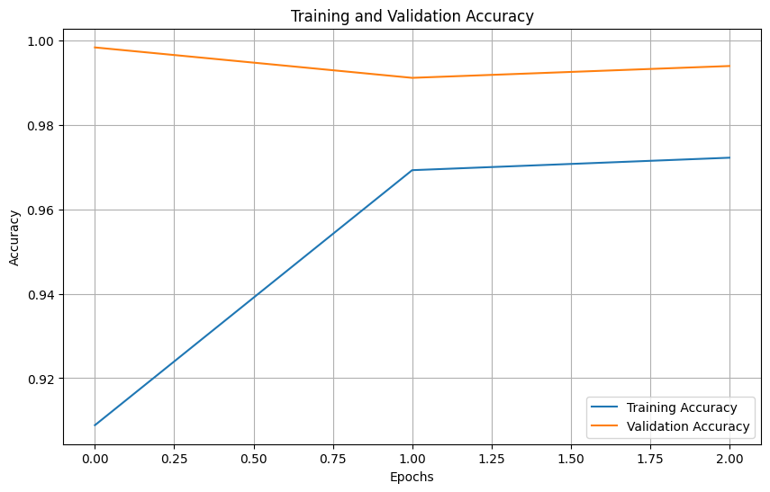

```python
# Get training and validation accuracy from the history object
train_accuracy = history1.history['accuracy']
val_accuracy = history1.history['val_accuracy']

# Plot training and validation accuracy
plt.figure(figsize=(10, 6))
plt.plot(train_accuracy, label='Training Accuracy')
plt.plot(val_accuracy, label='Validation Accuracy')
plt.xlabel('Epochs')
plt.ylabel('Accuracy')
plt.title('Training and Validation Accuracy')
plt.legend()
plt.grid(True)
plt.show()
```

### Evaluating the model

```python
# Evaluate the model to calculate the accuracy
accuracy = model2.evaluate(test_images, test_labels, verbose=1)

print('\n', 'Test_Accuracy:-', accuracy[1])
```

```
 Test_Accuracy:- 0.9761538505554199
```

**Generate the classification report and confusion matrix**

```
              precision    recall  f1-score   support

           0       0.96      0.99      0.98      1300
           1       0.99      0.96      0.98      1300

    accuracy                           0.98      2600
   macro avg       0.98      0.98      0.98      2600
weighted avg       0.98      0.98      0.98      2600
```

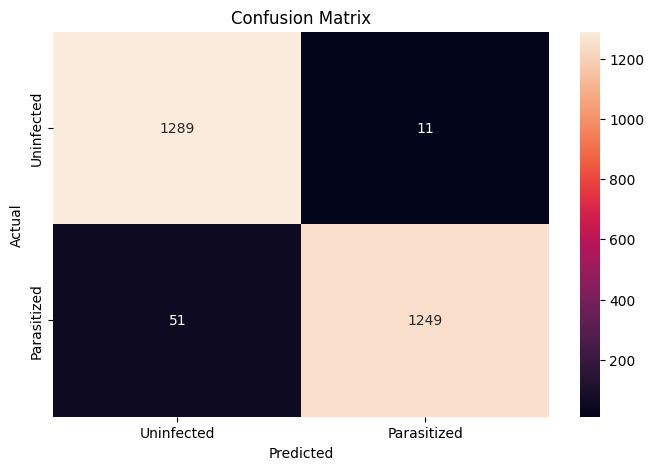

```python
# Make predictions on the test set
pred = model2.predict(test_images)

# Convert predictions and true labels to class indices
pred = np.argmax(pred, axis=1)
y_true = np.argmax(test_labels, axis=1)

# Printing the classification report
print(classification_report(y_true, pred))

# Plotting the heatmap using confusion matrix
cm = confusion_matrix(y_true, pred)

plt.figure(figsize=(8, 5))
sns.heatmap(cm, annot=True, fmt='.0f', xticklabels=['Uninfected', 'Parasitized'], yticklabels=['Uninfected', 'Parasitized'])
plt.ylabel('Actual')
plt.xlabel('Predicted')
plt.title('Confusion Matrix')
plt.show()
```

### Model 3 with Data Augmentation

```python
backend.clear_session() # Clearing backend for new model
```

### Using image data generator

```python
from sklearn.model_selection import train_test_split
from tensorflow.keras.preprocessing.image import ImageDataGenerator

# Splitting the data into training and validation sets
X_train, X_val, y_train, y_val = train_test_split(train_images, train_labels, test_size=0.2, random_state=42)

# Using ImageDataGenerator to generate images
train_datagen = ImageDataGenerator(horizontal_flip=True,
                                   zoom_range=0.5,
                                   rotation_range=30)

val_datagen = ImageDataGenerator()

# Flowing training images using train_datagen generator
train_generator = train_datagen.flow(x=X_train, y=y_train, batch_size=64, seed=42, shuffle=True)

# Flowing validation images using val_datagen generator
val_generator = val_datagen.flow(x=X_val, y=y_val, batch_size=64, seed=42, shuffle=True)
```

### Check if the performance of the model can be improved by changing different parameters in the ImageDataGenerator.

#### Visualizing Augmented images

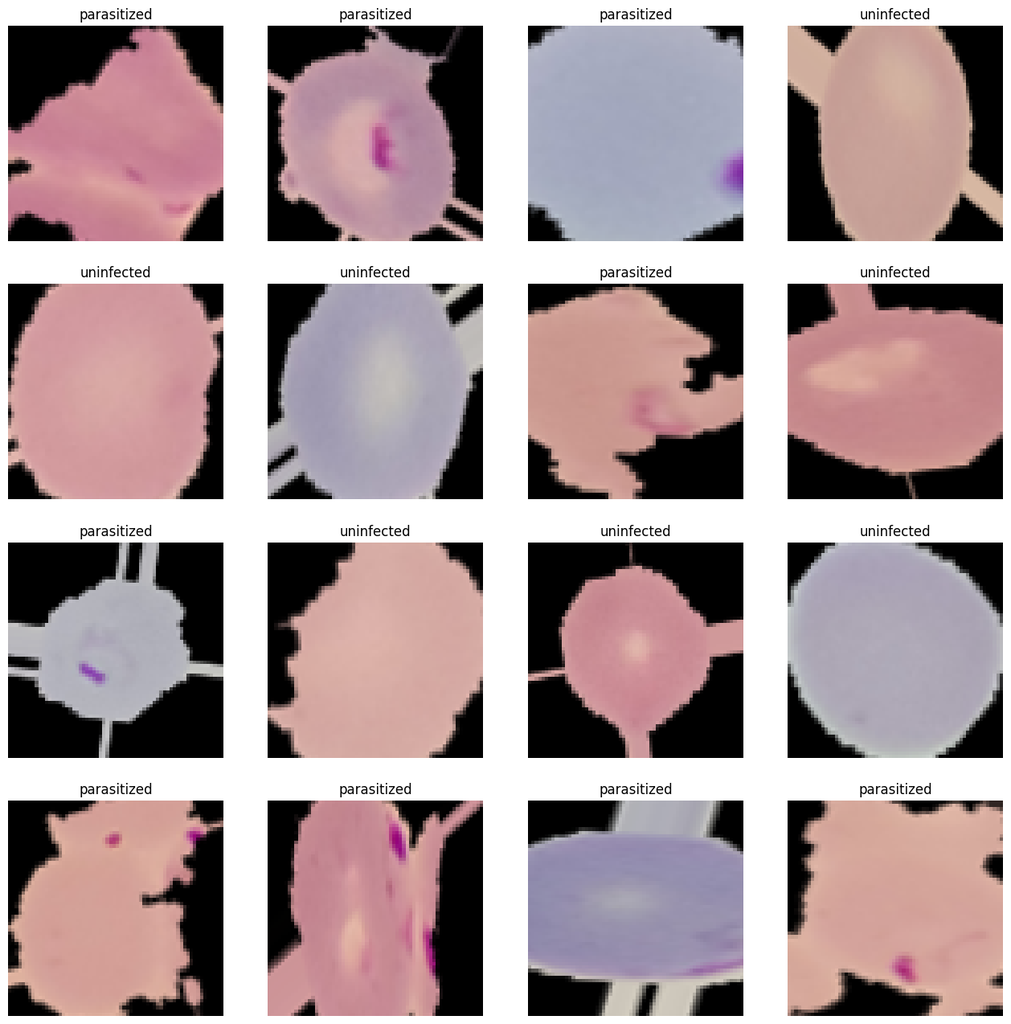

```python
# Creating an iterable for images and labels from the training data
images, labels = next(train_generator)

# Plotting 16 images from the training data
fig, axes = plt.subplots(4, 4, figsize = (16, 8))

fig.set_size_inches(16, 16)
for (image, label, ax) in zip(images, labels, axes.flatten()):

    ax.imshow(image)

    if label[1] == 1:

        ax.set_title('parasitized')

    else:

        ax.set_title('uninfected')

    ax.axis('off')
```

### Building the Model

```python
from tensorflow.keras import backend, optimizers

# Clearing the backend for the new model
backend.clear_session()

# Building Model 3
model3 = Sequential()

model3.add(Conv2D(filters=64, kernel_size=3, padding="same", input_shape=(64, 64, 3)))
model3.add(BatchNormalization())
model3.add(LeakyReLU(alpha=0.1))
model3.add(MaxPooling2D(pool_size=2))
model3.add(Dropout(0.25))

model3.add(Conv2D(filters=128, kernel_size=3, padding="same"))
model3.add(BatchNormalization())
model3.add(LeakyReLU(alpha=0.1))
model3.add(MaxPooling2D(pool_size=2))
model3.add(Dropout(0.3))

model3.add(Conv2D(filters=256, kernel_size=3, padding="same"))
model3.add(BatchNormalization())
model3.add(LeakyReLU(alpha=0.1))
model3.add(MaxPooling2D(pool_size=2))
model3.add(Dropout(0.35))

model3.add(Conv2D(filters=512, kernel_size=3, padding="same"))
model3.add(BatchNormalization())
model3.add(LeakyReLU(alpha=0.1))
model3.add(MaxPooling2D(pool_size=2))
model3.add(Dropout(0.4))

# Flatten the output from the convolutional layers
model3.add(Flatten())

# Add dense layers
model3.add(Dense(units=512))
model3.add(BatchNormalization())
model3.add(LeakyReLU(alpha=0.1))
model3.add(Dropout(0.5))

# Add the output layer
model3.add(Dense(units=2, activation='softmax'))

# Compile the model
adam = optimizers.Adam(learning_rate=0.001)
model3.compile(loss='binary_crossentropy', optimizer=adam, metrics=['accuracy'])

# Print the model summary
model3.summary()
```

```
Model: "sequential"
_________________________________________________________________
 Layer (type)                Output Shape              Param #
=================================================================
 conv2d (Conv2D)             (None, 64, 64, 64)        1792

 batch_normalization (Batch  (None, 64, 64, 64)        256
 Normalization)

 leaky_re_lu (LeakyReLU)     (None, 64, 64, 64)        0

 max_pooling2d (MaxPooling2  (None, 32, 32, 64)        0
 D)

 dropout (Dropout)           (None, 32, 32, 64)        0

 conv2d_1 (Conv2D)           (None, 32, 32, 128)       73856

 batch_normalization_1 (Bat  (None, 32, 32, 128)       512
 chNormalization)

 leaky_re_lu_1 (LeakyReLU)   (None, 32, 32, 128)       0

 max_pooling2d_1 (MaxPoolin  (None, 16, 16, 128)       0
 g2D)

 dropout_1 (Dropout)         (None, 16, 16, 128)       0

 conv2d_2 (Conv2D)           (None, 16, 16, 256)       295168

 batch_normalization_2 (Bat  (None, 16, 16, 256)       1024
 chNormalization)

 leaky_re_lu_2 (LeakyReLU)   (None, 16, 16, 256)       0

 max_pooling2d_2 (MaxPoolin  (None, 8, 8, 256)         0
 g2D)

 dropout_2 (Dropout)         (None, 8, 8, 256)         0

```

[output cut: 15 more lines]

```

 batch_normalization_4 (Bat  (None, 512)               2048
 chNormalization)

 leaky_re_lu_4 (LeakyReLU)   (None, 512)               0

 dropout_4 (Dropout)         (None, 512)               0

 dense_1 (Dense)             (None, 2)                 1026

=================================================================
Total params: 5752706 (21.94 MB)
Trainable params: 5749762 (21.93 MB)
Non-trainable params: 2944 (11.50 KB)
_________________________________________________________________
```

**Using Callbacks**

```python
callbacks = [EarlyStopping(monitor = 'val_loss', patience = 2),
             ModelCheckpoint('.mdl_wts.hdf5', monitor = 'val_loss', save_best_only = True)]
```

**Fit and Train the model**

```python
history3 = model3.fit(train_generator,
                      validation_data=val_generator,
                      batch_size=64, callbacks=callbacks,
                      epochs=20, verbose=1)
```

### **Evaluating the model**

**Plot the train and validation accuracy**

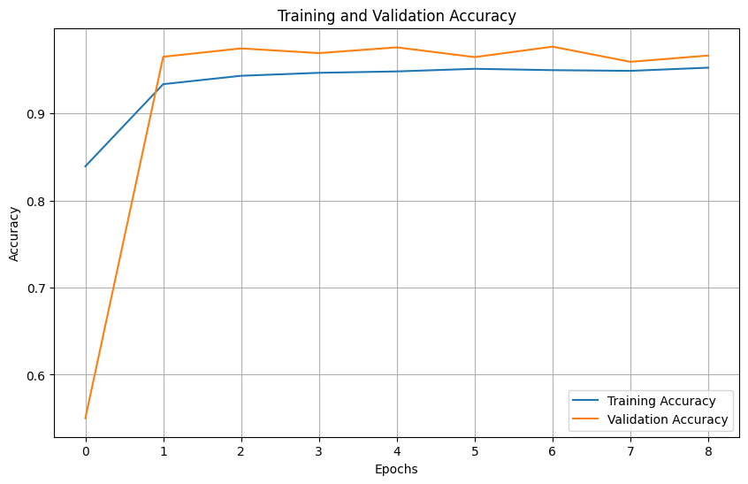

```python
plot_accuracy(history3)
```

```python
# Evaluating the model on test data
accuracy3 = model3.evaluate(test_images, test_labels, verbose=1)

print('\n', 'Test_Accuracy:-', accuracy3[1])
```

```
 Test_Accuracy:- 0.9649999737739563
```

**Plotting the classification report and confusion matrix**

```
              precision    recall  f1-score   support

           0       0.95      0.99      0.97      1300
           1       0.98      0.94      0.96      1300

    accuracy                           0.96      2600
   macro avg       0.97      0.97      0.96      2600
weighted avg       0.97      0.96      0.96      2600
```

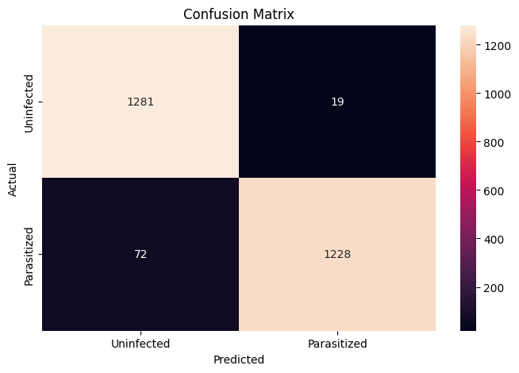

```python
# Make predictions on the test set
pred = model3.predict(test_images)

# Convert predictions and true labels to class indices
pred = np.argmax(pred, axis=1)
y_true = np.argmax(test_labels, axis=1)

# Printing the classification report
print(classification_report(y_true, pred))

# Plotting the heatmap using confusion matrix
cm = confusion_matrix(y_true, pred)

plt.figure(figsize=(8, 5))
sns.heatmap(cm, annot=True, fmt='.0f', xticklabels=['Uninfected', 'Parasitized'], yticklabels=['Uninfected', 'Parasitized'])
plt.ylabel('Actual')
plt.xlabel('Predicted')
plt.title('Confusion Matrix')
plt.show()
```

**Now, let us try to use a pretrained model like VGG16 and check how it performs on our data.**

### **Pre-trained model (VGG16)**

```python
# Clearing backend
from tensorflow.keras import backend

backend.clear_session()

# Fixing the seed for random number generators
np.random.seed(42)

import random

random.seed(42)

tf.random.set_seed(42)
```

```python
from tensorflow.keras.applications.vgg16 import VGG16
from tensorflow.keras import Model

vgg = VGG16(include_top=False, weights='imagenet', input_shape=(64, 64, 3))

vgg.summary()
```

```
Downloading data from https://storage.googleapis.com/tensorflow/keras-applications/vgg16/vgg16_weights_tf_dim_ordering_tf_kernels_notop.h5
Model: "vgg16"
_________________________________________________________________
 Layer (type)                Output Shape              Param #
=================================================================
 input_1 (InputLayer)        [(None, 64, 64, 3)]       0

 block1_conv1 (Conv2D)       (None, 64, 64, 64)        1792

 block1_conv2 (Conv2D)       (None, 64, 64, 64)        36928

 block1_pool (MaxPooling2D)  (None, 32, 32, 64)        0

 block2_conv1 (Conv2D)       (None, 32, 32, 128)       73856

 block2_conv2 (Conv2D)       (None, 32, 32, 128)       147584

 block2_pool (MaxPooling2D)  (None, 16, 16, 128)       0

 block3_conv1 (Conv2D)       (None, 16, 16, 256)       295168

 block3_conv2 (Conv2D)       (None, 16, 16, 256)       590080

 block3_conv3 (Conv2D)       (None, 16, 16, 256)       590080

 block3_pool (MaxPooling2D)  (None, 8, 8, 256)         0

 block4_conv1 (Conv2D)       (None, 8, 8, 512)         1180160

 block4_conv2 (Conv2D)       (None, 8, 8, 512)         2359808

 block4_conv3 (Conv2D)       (None, 8, 8, 512)         2359808

 block4_pool (MaxPooling2D)  (None, 4, 4, 512)         0

 block5_conv1 (Conv2D)       (None, 4, 4, 512)         2359808

 block5_conv2 (Conv2D)       (None, 4, 4, 512)         2359808

 block5_conv3 (Conv2D)       (None, 4, 4, 512)         2359808

 block5_pool (MaxPooling2D)  (None, 2, 2, 512)         0

=================================================================
Total params: 14714688 (56.13 MB)
Trainable params: 14714688 (56.13 MB)
Non-trainable params: 0 (0.00 Byte)
_________________________________________________________________
```

```python
transfer_layer = vgg.get_layer('block5_pool')

vgg.trainable = False

# Add classification layers on top of it
x = Flatten()(transfer_layer.output)  # Flatten the output from the 3rd block of the VGG16 model

x = Dense(256, activation='relu')(x)
x = Dropout(0.3)(x)

x = Dense(128, activation='relu')(x)
x = Dropout(0.3)(x)

x = Dense(64, activation='relu')(x)
x = BatchNormalization()(x)

pred = Dense(2, activation='softmax')(x)  # Output layer with 2 neurons for binary classification

model4 = Model(vgg.input, pred)  # Initializing the model

# Print the model summary
model4.summary()
```

```
Model: "model"
_________________________________________________________________
 Layer (type)                Output Shape              Param #
=================================================================
 input_1 (InputLayer)        [(None, 64, 64, 3)]       0

 block1_conv1 (Conv2D)       (None, 64, 64, 64)        1792

 block1_conv2 (Conv2D)       (None, 64, 64, 64)        36928

 block1_pool (MaxPooling2D)  (None, 32, 32, 64)        0

 block2_conv1 (Conv2D)       (None, 32, 32, 128)       73856

 block2_conv2 (Conv2D)       (None, 32, 32, 128)       147584

 block2_pool (MaxPooling2D)  (None, 16, 16, 128)       0

 block3_conv1 (Conv2D)       (None, 16, 16, 256)       295168

 block3_conv2 (Conv2D)       (None, 16, 16, 256)       590080

 block3_conv3 (Conv2D)       (None, 16, 16, 256)       590080

 block3_pool (MaxPooling2D)  (None, 8, 8, 256)         0

 block4_conv1 (Conv2D)       (None, 8, 8, 512)         1180160

 block4_conv2 (Conv2D)       (None, 8, 8, 512)         2359808

 block4_conv3 (Conv2D)       (None, 8, 8, 512)         2359808

 block4_pool (MaxPooling2D)  (None, 4, 4, 512)         0

 block5_conv1 (Conv2D)       (None, 4, 4, 512)         2359808

 block5_conv2 (Conv2D)       (None, 4, 4, 512)         2359808

 block5_conv3 (Conv2D)       (None, 4, 4, 512)         2359808

```

[output cut: 9 more lines]

```

 dropout_1 (Dropout)         (None, 128)               0

 dense_2 (Dense)             (None, 64)                8256

 batch_normalization (Batch  (None, 64)                256
 Normalization)

 dense_3 (Dense)             (None, 2)                 130

=================================================================
Total params: 15280770 (58.29 MB)
Trainable params: 565954 (2.16 MB)
Non-trainable params: 14714816 (56.13 MB)
_________________________________________________________________
```

### Compiling the model

```python
# Compiling the model
adam = optimizers.Adam(learning_rate=0.001)
model4.compile(loss='binary_crossentropy', optimizer=adam, metrics=['accuracy'])

# Print the model summary
model4.summary()
```

```
Model: "model"
_________________________________________________________________
 Layer (type)                Output Shape              Param #
=================================================================
 input_1 (InputLayer)        [(None, 64, 64, 3)]       0

 block1_conv1 (Conv2D)       (None, 64, 64, 64)        1792

 block1_conv2 (Conv2D)       (None, 64, 64, 64)        36928

 block1_pool (MaxPooling2D)  (None, 32, 32, 64)        0

 block2_conv1 (Conv2D)       (None, 32, 32, 128)       73856

 block2_conv2 (Conv2D)       (None, 32, 32, 128)       147584

 block2_pool (MaxPooling2D)  (None, 16, 16, 128)       0

 block3_conv1 (Conv2D)       (None, 16, 16, 256)       295168

 block3_conv2 (Conv2D)       (None, 16, 16, 256)       590080

 block3_conv3 (Conv2D)       (None, 16, 16, 256)       590080

 block3_pool (MaxPooling2D)  (None, 8, 8, 256)         0

 block4_conv1 (Conv2D)       (None, 8, 8, 512)         1180160

 block4_conv2 (Conv2D)       (None, 8, 8, 512)         2359808

 block4_conv3 (Conv2D)       (None, 8, 8, 512)         2359808

 block4_pool (MaxPooling2D)  (None, 4, 4, 512)         0

 block5_conv1 (Conv2D)       (None, 4, 4, 512)         2359808

 block5_conv2 (Conv2D)       (None, 4, 4, 512)         2359808

 block5_conv3 (Conv2D)       (None, 4, 4, 512)         2359808

```

[output cut: 9 more lines]

```

 dropout_1 (Dropout)         (None, 128)               0

 dense_2 (Dense)             (None, 64)                8256

 batch_normalization (Batch  (None, 64)                256
 Normalization)

 dense_3 (Dense)             (None, 2)                 130

=================================================================
Total params: 15280770 (58.29 MB)
Trainable params: 565954 (2.16 MB)
Non-trainable params: 14714816 (56.13 MB)
_________________________________________________________________
```

### Using callbacks

```python
from tensorflow.keras.callbacks import EarlyStopping, ModelCheckpoint

callbacks = [
    EarlyStopping(monitor='val_loss', patience=2),
    ModelCheckpoint('.mdl_wts.hdf5', monitor='val_loss', save_best_only=True)
]
```

**Fit and Train the model**

```python
history4 = model4.fit(
    train_generator,
    validation_data=val_generator,
    epochs=10,
    callbacks=callbacks,
    verbose=1
)
```

**Plot the train and validation accuracy**

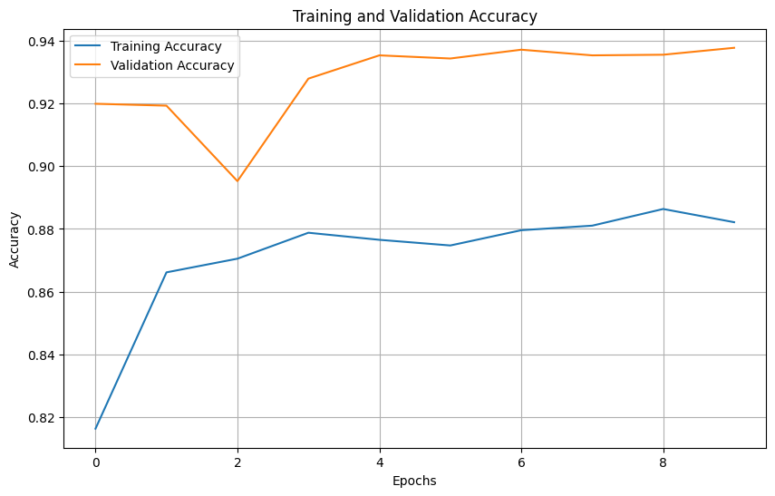

```python
plot_accuracy(history4)
```

### Evaluating the model

```python
# Evaluating the model on test data
accuracy4 = model4.evaluate(test_images, test_labels, verbose=1)

print('\n', 'Test_Accuracy:-', accuracy4[1])
```

```
 Test_Accuracy:- 0.935769259929657
```

**Plotting the classification report and confusion matrix**

```
              precision    recall  f1-score   support

           0       0.94      0.94      0.94      1300
           1       0.94      0.94      0.94      1300

    accuracy                           0.94      2600
   macro avg       0.94      0.94      0.94      2600
weighted avg       0.94      0.94      0.94      2600
```

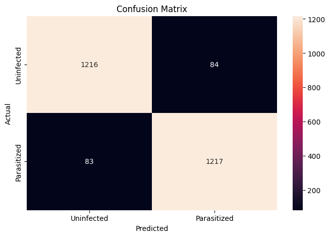

```python
# Generate predictions
pred4 = model4.predict(test_images)

# Convert predictions and true labels to class indices
pred4 = np.argmax(pred4, axis=1)
y_true = np.argmax(test_labels, axis=1)

# Print classification report
print(classification_report(y_true, pred4))

# Plot confusion matrix
cm4 = confusion_matrix(y_true, pred4)
plt.figure(figsize=(8, 5))
sns.heatmap(cm4, annot=True, fmt='.0f', xticklabels=['Uninfected', 'Parasitized'], yticklabels=['Uninfected', 'Parasitized'])
plt.ylabel('Actual')
plt.xlabel('Predicted')
plt.title('Confusion Matrix')
plt.show()
```

### Evaluate all the models at once

```python
def evaluate_model(model, test_images, test_labels, model_name):
    # Generate predictions
    pred = model.predict(test_images)
    pred = np.argmax(pred, axis=1)
    y_true = np.argmax(test_labels, axis=1)

    # Print classification report
    print(f"{model_name} Classification Report:")
    print(classification_report(y_true, pred))

    # Plot confusion matrix
    cm = confusion_matrix(y_true, pred)
    print(f"{model_name} Confusion Matrix:")
    print(cm)
    plt.figure(figsize=(8, 5))
    sns.heatmap(cm, annot=True, fmt='.0f', xticklabels=['Uninfected', 'Parasitized'], yticklabels=['Uninfected', 'Parasitized'])
    plt.ylabel('Actual')
    plt.xlabel('Predicted')
    plt.title(f'{model_name} Confusion Matrix')
    plt.show()
```

```
Model 0 Classification Report:
              precision    recall  f1-score   support

           0       0.98      0.99      0.98      1300
           1       0.99      0.98      0.98      1300

    accuracy                           0.98      2600
   macro avg       0.98      0.98      0.98      2600
weighted avg       0.98      0.98      0.98      2600

Model 0 Confusion Matrix:
[[1282   18]
 [  25 1275]]
```

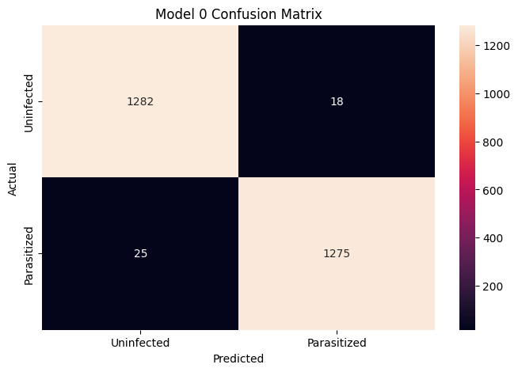

```
Model 1 Classification Report:
              precision    recall  f1-score   support

           0       0.95      0.99      0.97      1300
           1       0.99      0.94      0.97      1300

    accuracy                           0.97      2600
   macro avg       0.97      0.97      0.97      2600
weighted avg       0.97      0.97      0.97      2600

Model 1 Confusion Matrix:
[[1293    7]
 [  75 1225]]
```

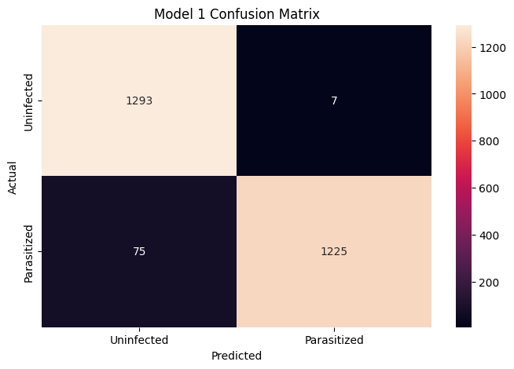

```
Model 2 Classification Report:
              precision    recall  f1-score   support

           0       0.96      0.99      0.98      1300
           1       0.99      0.96      0.98      1300

    accuracy                           0.98      2600
   macro avg       0.98      0.98      0.98      2600
weighted avg       0.98      0.98      0.98      2600

Model 2 Confusion Matrix:
[[1289   11]
 [  51 1249]]
```

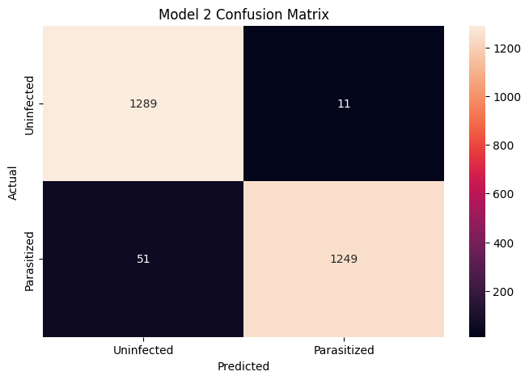

```
Model 3 Classification Report:
              precision    recall  f1-score   support

           0       0.95      0.99      0.97      1300
           1       0.98      0.94      0.96      1300

    accuracy                           0.96      2600
   macro avg       0.97      0.97      0.96      2600
weighted avg       0.97      0.96      0.96      2600

Model 3 Confusion Matrix:
[[1281   19]
 [  72 1228]]
```

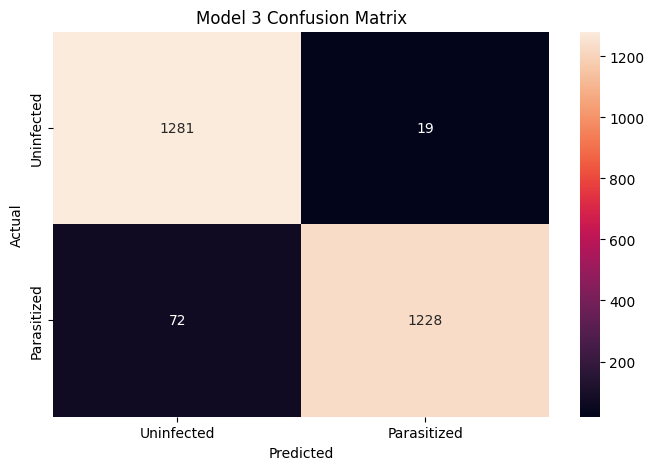

```
Model 4 (VGG16-based) Classification Report:
              precision    recall  f1-score   support

           0       0.94      0.94      0.94      1300
           1       0.94      0.94      0.94      1300

    accuracy                           0.94      2600
   macro avg       0.94      0.94      0.94      2600
weighted avg       0.94      0.94      0.94      2600

Model 4 (VGG16-based) Confusion Matrix:
[[1216   84]
 [  83 1217]]
```

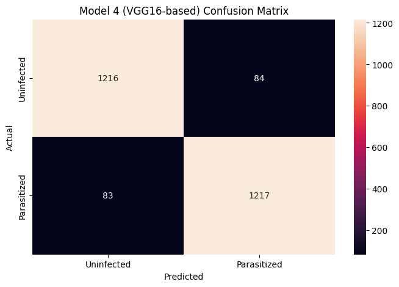

```python
# Call the function for each model
evaluate_model(model, test_images, test_labels, "Model 0")
evaluate_model(model1, test_images, test_labels, "Model 1")
evaluate_model(model2, test_images, test_labels, "Model 2")
evaluate_model(model3, test_images, test_labels, "Model 3")
evaluate_model(model4, test_images, test_labels, "Model 4 (VGG16-based)")
```

```python
backend.clear_session() # Clearing backend for new model
```

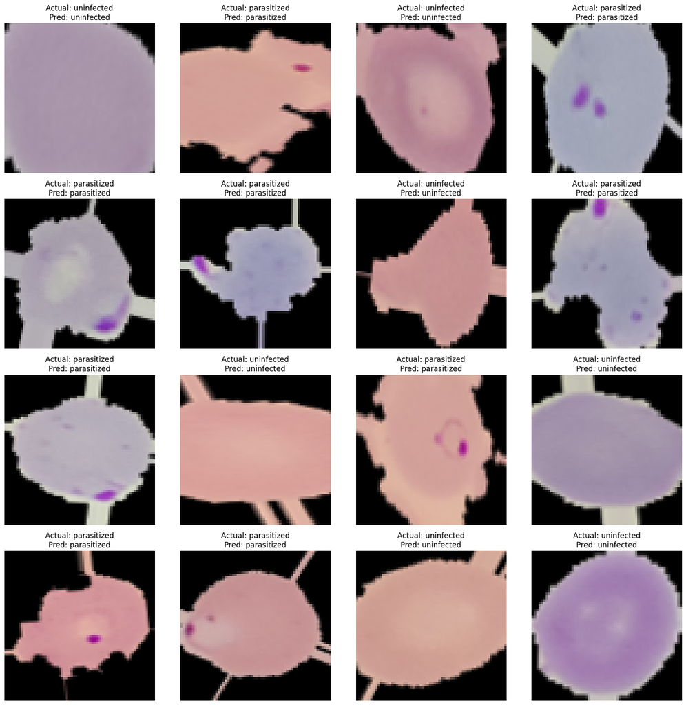

```python
def generate_and_visualize_predictions(random_seed, best_model):
    # Creating a new train generator with a different seed
    train_generator = train_datagen.flow(x=X_train, y=y_train, batch_size=16, seed=random_seed, shuffle=True)

    # Generate a batch of augmented images
    images, labels = next(train_generator)

    # Make predictions on the augmented images using the provided model
    predictions = model.predict(images)
    predictions = np.argmax(predictions, axis=1)
    true_labels = np.argmax(labels, axis=1)

    # Plotting the images with actual and predicted labels
    fig, axes = plt.subplots(4, 4, figsize=(16, 8))
    fig.set_size_inches(16, 16)

    for (image, true_label, pred_label, ax) in zip(images, true_labels, predictions, axes.flatten()):
        ax.imshow(image)
        if true_label == 1:
            true_label_text = 'parasitized'
        else:
            true_label_text = 'uninfected'

        if pred_label == 1:
            pred_label_text = 'parasitized'
        else:
            pred_label_text = 'uninfected'

        ax.set_title(f"Actual: {true_label_text}\nPred: {pred_label_text}")
        ax.axis('off')

    plt.tight_layout()
    plt.show()

# Generate and visualize predictions for a batch of augmented images with a different seed
generate_and_visualize_predictions(random_seed=100, best_model=model)
```

### Insights

#### Refined Insights:

- **Model 0** achieves the highest overall accuracy (0.98) among all models, with excellent precision, recall, and f1-scores.
- **Model 2** also performs very well, matching Model 0's accuracy (0.98) and having high precision, recall, and f1-scores.
- **Model 1** shows slightly lower performance compared to Models 0 and 2 but still achieves high accuracy (0.97).
- **Model 3** and **Model 4 (VGG16-based)** have lower accuracy, with Model 3 at 0.96 and Model 4 at 0.94, indicating room for improvement.

### Proposal for the Final Solution Design:

I propose adopting **Model 0** for the final solution. Here's why:

- **Performance**: It has the highest accuracy (0.98) and consistently high precision, recall, and f1-scores across both classes.
- **Reliability**: The low number of misclassifications in the confusion matrix signifies a robust model that minimizes both false positives and negatives.
- **Feasibility**: Model 0's architecture can be further fine-tuned or integrated with data augmentation techniques to potentially enhance performance further.

### Potential Improvements:

- **Data Augmentation**: Applying additional augmentation techniques might help improve model generalization.
- **Hyperparameter Tuning**: Further tuning of hyperparameters such as learning rate, batch size, and dropout rates might yield better results.
- **Ensemble Methods**: Combining the predictions of multiple models (ensemble) can often boost performance.